# Real Data Analysis in BSDE Projects

Mengqi Zhang, Richard Guo

2021-03-25

# 1 Introduction

This markdown is for individual case-control study based on Barycenter and Wasserstein distance estimation on the gene differential expression (DE) analysis of certain cell type based on the idiopathic pulmonary fibrosis.

# 2 Initial Setup

R packages required in this pipeline:

```r
library("MASS")
library("emdbook")
library("moments")
library("MAST")
library("lme4")
library("DESeq2")
library("abind")
library("doRNG")
library("reticulate")
library("BSDE")
```

# 3 Computation

Here we present a demo version of our real data analysis,We take the basic parameters, i.e., the mean, dispersion and dropout parameter from the distribution of the real reference scRNAseq database from paper [Single-cell RNA sequencing identifies diverse roles of epithelial cells in idiopathic pulmonary fibrosis](https://www.ncbi.nlm.nih.gov/pmc/articles/PMC5135277/).

We focus on the cell type SCGB3A2+ and limit our analysis in the first 1000 genes.The trimmed file are at the data/IPF folder.

## 3.1 Basic Settings

Senario settings in our analysis are as follows:

```r
#senarios
covariate_flag=NA #c(NA, "quantile99")
perm_label=0 #perm_label =0 means calculate the observed data other wise, permutated data
merge_method="python" # c("R","python","python_exp")
lambda_fold=2


dir = "~/Dropbox/Barycenter/BSDEpackage/BSDE/data/"
setwd(dir)
```

## 3.2 Data Preparation

```r
###########input###############
meta=readRDS(paste0(dir,"IPF/meta.rds"))

#input phenotype
cur_individual=unique(meta$individual)

#input bulk
rawM_bulk=readRDS(paste0(dir,"IPF/matrix_bulk.rds"))
rawM_cell=readRDS(paste0(dir,"IPF/ind_cellnum.rds"))
rawM_bulk=t(apply(rawM_bulk,1,function(x) x*100/rawM_cell))
colnames(rawM_bulk)=names(rawM_cell)
logcount_data_bulk=log2(rawM_bulk+1)

#input counts
rawM=readRDS(paste0(dir,"IPF/rawM.rds"))
logcount_data=log2(rawM+1)
dim(logcount_data)
```

```
## [1] 1000 3220
```

```r
dim(meta)
```

```
## [1] 3220   15
```

```r
meta_ind=meta[match(unique(meta$individual),meta$individual),c("individual","diagnosis")]

rdp=readRDS(paste0(dir,"IPF/ind_readdepth.rds"))

meta_ind$rdp=scale(rdp)
meta_ind$individual=scale(as.numeric(meta_ind$individual))
meta_ind$diagnosis=meta_ind$diagnosis
```

After read in the data, we apply inverse probability weight to remove the covariance effects.

Then we run our method for that.

```r
dim(logcount_data)
logcount_data[1:10,1:10]
cell_id=meta$cell
gene_id=dimnames(logcount_data)[[1]]
rownames(logcount_data)=gene_id
colnames(logcount_data)=cell_id

op_pvalw=matrix(ncol=1,nrow=nrow(logcount_data))

bc_case_ob=list()
bc_ctrl_ob=list()
bcw_case_ob=list()
bcw_ctrl_ob=list()
#for(ig in 1:nrow(logcount_data)){
for(ig in 1:10){

  bc_case_ob[[ig]]=list()
  bc_ctrl_ob[[ig]]=list()
  bcw_case_ob[[ig]]=list()
  bcw_ctrl_ob[[ig]]=list()

  cur_sim=logcount_data[ig,]
  cur_ind=meta$individual
  cur_pheno=meta$diagnosis

  tempa=tryCatch({cal_w2_pval(count_per_gene=cur_sim,meta_individual=cur_ind,meta_phenotype=cur_pheno,perm_num=200,unif_round_unit=0.5,l_fold=lambda_fold,merge_method=merge_method,weight=ipww,shrink=FALSE)}, error = function(e) {NA} )
  op_pvalw[ig]=tryCatch({tempa[[1]]}, error = function(e) {NA} )
  bcw_case_ob[[ig]]=tryCatch({tempa[[2]]}, error = function(e) {NA} )
  bcw_ctrl_ob[[ig]]=tryCatch({tempa[[3]]}, error = function(e) {NA} )
  if(!(is.na(op_pvalw[ig])) && op_pvalw[ig]<2/200){
    op_pvalw[ig]=tryCatch({cal_w2_pval(count_per_gene=cur_sim,meta_individual=cur_ind,meta_phenotype=cur_pheno,perm_num=1000,unif_round_unit=0.5,l_fold=lambda_fold,merge_method=merge_method,weight=ipww,shrink=FALSE)[[1]]}, error = function(e) {NA} )}
  if(!(is.na(op_pvalw[ig])) && op_pvalw[ig]<2/1000){
    op_pvalw[ig]=tryCatch({cal_w2_pval(count_per_gene=cur_sim,meta_individual=cur_ind,meta_phenotype=cur_pheno,perm_num=5000,unif_round_unit=0.5,l_fold=lambda_fold,merge_method=merge_method,weight=ipww,shrink=FALSE)[[1]]}, error = function(e) {NA} )}
}

names(op_pvalw)=gene_id
```

# 4 Result Visualization

Once got the p-values, we can present our results as follows.

## 4.1 Data Preparation

We’ve done our the analysis based on the top 3000 expressed genes among all clusters, and use FDR method multi-effect correction. Then we will do some data analysis and visualization.

```r
n_cluster=31
case_col="#00539B"
ctrl_col="#a3d6f0" #"#4B9CD3"

set.seed(1)
library(ggplot2)
library(stringr)
library(scales)

#geom_split_violin function
GeomSplitViolin <- ggproto("GeomSplitViolin", GeomViolin,
                           draw_group = function(self, data, ..., draw_quantiles = NULL) {
                             data <- transform(data, xminv = x - violinwidth * (x - xmin), xmaxv = x + violinwidth * (xmax - x))
                             grp <- data[1, "group"]
                             newdata <- plyr::arrange(transform(data, x = if (grp %% 2 == 1) xminv else xmaxv), if (grp %% 2 == 1) y else -y)
                             newdata <- rbind(newdata[1, ], newdata, newdata[nrow(newdata), ], newdata[1, ])
                             newdata[c(1, nrow(newdata) - 1, nrow(newdata)), "x"] <- round(newdata[1, "x"])

                             if (length(draw_quantiles) > 0 & !scales::zero_range(range(data$y))) {
                               stopifnot(all(draw_quantiles >= 0), all(draw_quantiles <=
                                                                         1))
                               quantiles <- ggplot2:::create_quantile_segment_frame(data, draw_quantiles)
                               aesthetics <- data[rep(1, nrow(quantiles)), setdiff(names(data), c("x", "y")), drop = FALSE]
                               aesthetics$alpha <- rep(1, nrow(quantiles))
                               both <- cbind(quantiles, aesthetics)
                               quantile_grob <- GeomPath$draw_panel(both, ...)
                               ggplot2:::ggname("geom_split_violin", grid::grobTree(GeomPolygon$draw_panel(newdata, ...), quantile_grob))
                             }
                             else {
                               ggplot2:::ggname("geom_split_violin", GeomPolygon$draw_panel(newdata, ...))
                             }
                           })

geom_split_violin <- function(mapping = NULL, data = NULL, stat = "ydensity", position = "identity", ...,
                              draw_quantiles = NULL, trim = TRUE, scale = "area", na.rm = FALSE,
                              show.legend = NA, inherit.aes = TRUE) {
  layer(data = data, mapping = mapping, stat = stat, geom = GeomSplitViolin,
        position = position, show.legend = show.legend, inherit.aes = inherit.aes,
        params = list(trim = trim, scale = scale, draw_quantiles = draw_quantiles, na.rm = na.rm, ...))
}

t_col = function(color, percent = 60, name = NULL) {
  #      color = color name
  #    percent = % transparency
  #       name = an optional name for the color

  ## Get RGB values for named color
  rgb.val <- col2rgb(color)

  ## Make new color using input color as base and alpha set by transparency
  t.col <- rgb(rgb.val[1], rgb.val[2], rgb.val[3],
               max = 255,
               alpha = (100 - percent) * 255 / 100,
               names = name)

  ## Save the color
  invisible(t.col)
}
```

```r
#read_in
opw_padj=readRDS(paste0(dir,"IPF/opw_padj.rds"))
gene_id=names(opw_padj[[1]])
tmeta=readRDS(paste0(dir,"IPF/tmeta.rds"))
cell_num_table=readRDS(paste0(dir,"IPF/cell_num_table.rds"))
cluster=unique(tmeta$cluster)
total_individual=unique(tmeta$individual)

cur_cluster="Proliferating Epithelial Cells" #Proliferating Epithelial Cells  #Plasma Cells #Endothelial Cells
cluster=unique(tmeta$celltype)
cluster_plot=gsub("Proliferating","P.",cluster)
cluster_plot=gsub("Differentiating","Diff.",cluster_plot)
cluster_plot=gsub("Transitional","Trans.",cluster_plot)
cluster_plot=gsub("+ SCGB1A","/",cluster_plot)
```

## 4.2 Boxplot of the number of cells per subjects.

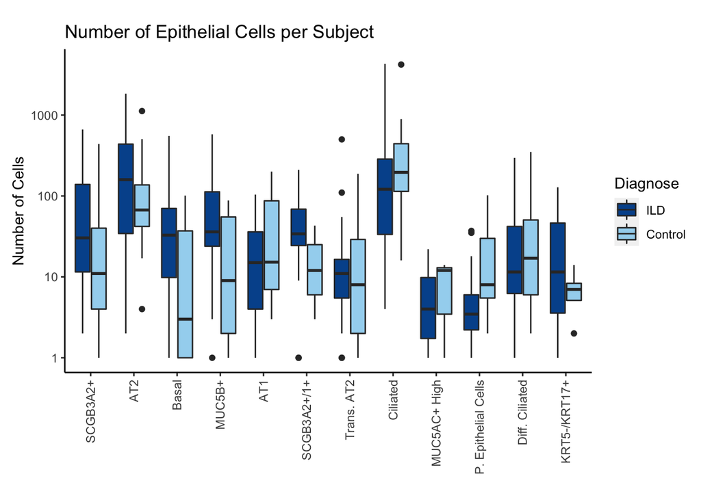

```r
pval_num=sapply(opw_padj,function(x){sum(x<=0.1,na.rm=TRUE)}) #adjusted FDR <0.1

population=tmeta$population[match(cluster,tmeta$cluster)]
sub_cluster_index=which(population=="Epithelial")

diagnose=tmeta$Status[match(total_individual,tmeta$individual)]
cell_num_table=cell_num_table[sub_cluster_index,]
pval_num=pval_num[sub_cluster_index]
porder=order(pval_num,decreasing = TRUE)
this_table=data.frame(cell_num=as.numeric(cell_num_table),
                      cluster=factor(rep(cluster_plot[sub_cluster_index],times=ncol(cell_num_table))
                      ,levels=cluster_plot[sub_cluster_index][porder]),
                      Diagnose=factor(rep(diagnose,each=nrow(cell_num_table)),levels=c("ILD","Control")))
this_table$cur_col=rep(case_col,nrow(this_table))
this_table$cur_col[this_table$diagnose=="Control"]=ctrl_col

this_table=this_table[this_table$cell_num>0,]
#violin plot cell number
cols = hue_pal()(length(unique(this_table$cluster)))
cols2=sapply(cols,t_col)

p1=ggplot(this_table, aes(x=cluster, y=cell_num, fill=Diagnose)) +
  #scale_fill_manual(values=hue_pal()(2)) +
  scale_fill_manual(values=c(case_col,ctrl_col)) +
  labs(title="Number of Epithelial Cells per Subject",x=" ", y = "Number of Cells", tag = " ")+
  #geom_split_violin(trim=FALSE)+#geom_jitter(shape=16, position=position_jitter(0.2))+
  geom_boxplot()+ scale_y_continuous(trans='log10') +
  theme(panel.grid.major = element_blank(), panel.grid.minor = element_blank(),
        panel.background = element_blank(), axis.line = element_line(colour = "black"),
        #legend.position = "none",
        axis.text.x = element_text(angle = 90, vjust = 0.5, hjust=1))
print(p1)
```

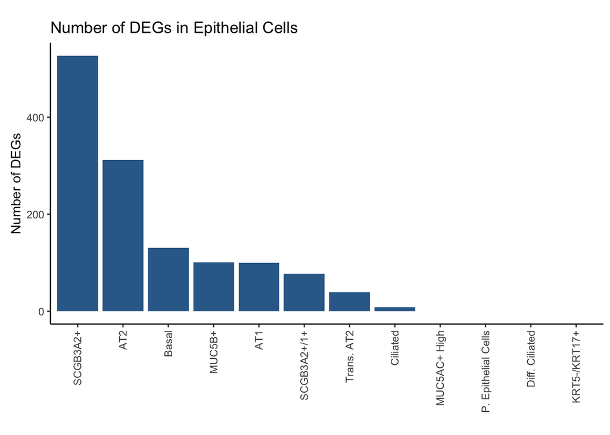

```r
this_table=data.frame(pval_num=pval_num,
                      cluster=factor(cluster_plot[sub_cluster_index],
                      levels=cluster_plot[sub_cluster_index][porder]))

p2=ggplot(this_table, aes(x=cluster, y=pval_num,fill=1)) +
  labs(title="Number of DEGs in Epithelial Cells",x=" ", y = "Number of DEGs", tag = " ")+
  geom_bar(stat="identity")+ #geom_jitter(shape=16, position=position_jitter(0.2))+
  theme(panel.grid.major = element_blank(), panel.grid.minor = element_blank(),
        panel.background = element_blank(), axis.line = element_line(colour = "black"),
        legend.position = "none",axis.text.x = element_text(angle = 90, vjust = 0.5, hjust=1))
print(p2)
```

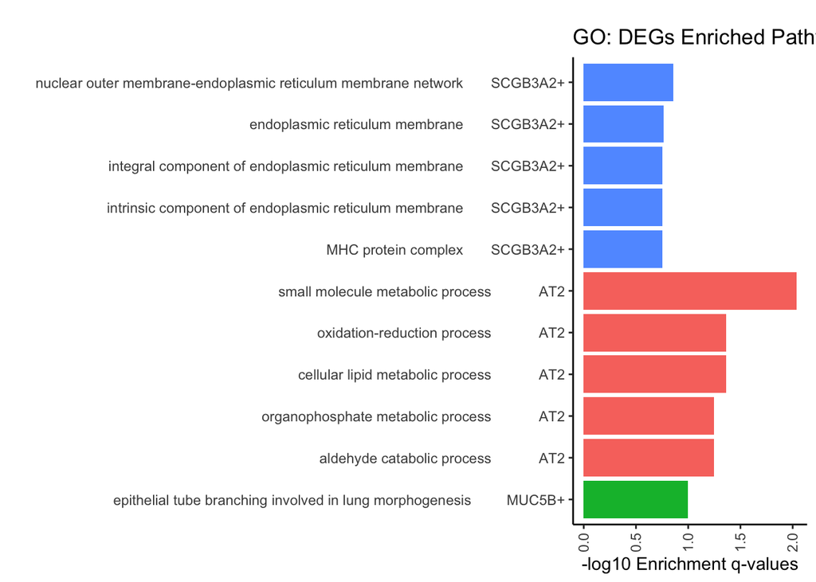

```r
p3=ggplot(go_table, aes(x=label, y=nlog10pval,fill=cluster)) +
  labs(title="GO: DEGs Enriched Pathways",x=" ", y = "-log10 Enrichment q-values", tag = " ")+
  geom_bar(stat="identity")+ #geom_jitter(shape=16, position=position_jitter(0.2))+
  coord_flip()+
  theme(panel.grid.major = element_blank(), panel.grid.minor = element_blank(),
        panel.background = element_blank(), axis.line = element_line(colour = "black"),
        legend.position = "none",axis.text.x = element_text(angle = 90, vjust = 0.5, hjust=1))
print(p3)
```